# CryptoAllAtOnce

Anika Larson

5/30/2016

For this risk estimate, we will use mcmodel and evalmcmod from the [mc2d](https://cran.r-project.org/web/packages/mc2d/index.html) package.

```r
# Load packages.
library(mc2d)
library(data.table)
```

### Define variables

Set the number of simulations for the variability and uncertainty dimensions.

```r
nsv <- 360
nsu <- 420
ndvar(nsv)  # Variability
```

```
## [1] 360
```

```r
ndunc(nsu)   # Uncertainty
```

```
## [1] 420
```

```r
rdv <- (nsu/3)
cwv <- (nsu/4)
div.nsv <- (nsv/3)
div5.nsv <- (nsv/5)
div5.nsu <- (nsu/5)
div7.nsu <- (nsu/7)
ns <- nsu * nsv
```

The *mc2d* functions will set `nsv` to `ndvar()` and `nsu` to `ndunc()` by default. Alternatively, we could supply these values to the *mc2d* model functions when we call them.

Define the variables we will use to set the `seed` for random sampling and the number of `digits` for `print()` statements.

```r
seed <- 2
digits <- 5
```

Introducing the bootstrapped dose-response data, fread command and sampling from Brian:

```r
alpha <- fread("output_dupont_crypto/alphalist.csv", sep = ',')
n50 <- fread("output_dupont_crypto/N50list.csv", sep = ',')
cdr <- merge(alpha,n50, by = "V1")
scdr <- cdr[sample(nrow(cdr), nsu, replace = TRUE), list(alpha, N50)] #sampling rows in the dose-response bootstrapped table equal to the number of simulations in the uncertainty dimension, aka NSU
```

Leaving that ^ for convenience, but since what we really want is a k-value list made of samples from the three different dose-response estimates (Dupont, Tamu, and UCP):

```r
k_dup <- fread("output_dupont_crypto/klist_dupont.csv", sep = ',')
gdrkD <- k_dup[sample(nrow(k_dup), div.nsv, replace = TRUE), list(k)] #sampling rows in the dose-response bootstrapped table equal to 1/3 the number of simulations in the uncertainty dimension, aka NSU
k_tamu <- fread("output_tamu_crypto/klist.csv", sep = ',')
gdrkT <- k_tamu[sample(nrow(k_tamu), div.nsv, replace = TRUE), list(k)]
k_ucp <- fread("output_UCP_crypto/klist.csv", sep = ',')
gdrkU <- k_ucp[sample(nrow(k_ucp), div.nsv, replace = TRUE), list(k)]
kval <- unlist(c(gdrkD,gdrkT,gdrkU))
```

Sampling from the Cryptosporidium custom distribution estimates:

```r
#Using the original custom distribution of estimates from aggregated cistern estimates:
cw.vlg1 <- fread("conc_data_aggreg.csv", sep = ',')
cw.vl.samp1 <- sample(cw.vlg1[,c(oocysts)], nsu, replace = TRUE)

#Using a combination of log-normal distributions from each of the the 5 different cisterns:
cw.vl.ln <- fread("concdata_percis.csv", sep = ',')
v1 <- cw.vl.ln[sample(nrow(cw.vl.ln), div7.nsu, replace = TRUE), list(c_v1_ln)]
colnames(v1) <- c("cw.vals")
v11 <- cw.vl.ln[sample(nrow(cw.vl.ln), div7.nsu, replace = TRUE), list(c_v11_ln)]
colnames(v11) <- c("cw.vals")
v2 <- cw.vl.ln[sample(nrow(cw.vl.ln), div7.nsu, replace = TRUE), list(c_v2_ln)]
colnames(v2) <- c("cw.vals")
v5 <- cw.vl.ln[sample(nrow(cw.vl.ln), div7.nsu, replace = TRUE), list(c_v5_ln)]
colnames(v5) <- c("cw.vals")
v8 <- cw.vl.ln[sample(nrow(cw.vl.ln), div7.nsu, replace = TRUE), list(c_v8a_ln)]
colnames(v8) <- c("cw.vals")
v9 <- cw.vl.ln[sample(nrow(cw.vl.ln), div7.nsu, replace = TRUE), list(c_v9a_ln)]
colnames(v9) <- c("cw.vals")
v10 <- cw.vl.ln[sample(nrow(cw.vl.ln), div7.nsu, replace = TRUE), list(c_v10_ln)]
colnames(v10) <- c("cw.vals")
cw.vlg2 <- unlist(c(v1$cw.vals,v11$cw.vals,v2$cw.vals,v5$cw.vals,v8$cw.vals,v9$cw.vals,v10$cw.vals))
cw.vl.samp2 <- sample(cw.vlg2, nsu, replace = TRUE)

#Determine which estimate to use: the original custom distribution (cw.vl.samp1) or the combined lognormal ditributions for each cistern (cw.vl.samp2).
cw.vl.samp <- cw.vl.samp2
```

[output not shown]

Sampling from the daily hosing exposure estimates distribution:

```r
  #Creating a distribution for hosing
  hose <- fread("exp_params/Hosing.csv", sep = ',')
  colnames(hose) <- c("trial","num", "mL")
  hose$hose_exp1 <- (hose$num * hose$mL)
  hose_exp <- hose[sample(nrow(hose), nsu, replace = TRUE), list(hose_exp1)]
```

Sampling from the daily showering exposure estimates distribution:

```r
  #Creating a distribution for showering
  shower <- fread("exp_params/Showers.csv", sep = ',')
  colnames(shower) <- c("trial","num", "mL")
  shower$shower_exp1 <- (shower$num * shower$mL)
  shower_exp <- shower[sample(nrow(shower), nsu, replace = TRUE), list(shower_exp1)]
```

### Define exposure model

Within the mcmodel function, use mcstoc to define “mc nodes” for each component of the model.

For each stochastic variable, use the `mcstoc()` function to create a “mcnode”, supply a probability function, the node type as “V” for variability or “U” for uncertainty, and any additional parameters to be passed to the probability function.

For deterministic variables, create nodes with the `mcdata()` function using the “0” type.

We will model the deterministic factors as uniform probablity distributions.

The last statement makes an “mc” object using the mc function.

```r
# Define an exposure model for evaluation by evalmcmod().
expo.mod1 <- mcmodel({
  # Values from Example 6.18 from Quantitative Microbial Risk Assessment,
  # 2nd Edition by Charles N. Haas, Joan B. Rose, and Charles P. Gerba.
  # (Wiley, 2014), pp. 215-216. Other fictitious values are noted below.

   # Cistern water viral loading (viruses/L):
  cw.vl1 <- mcdata(cw.vl.samp, type = "U")
  cw.vl2 <- mcstoc(rempiricalD, type = "VU", values = cw.vl.samp)
  cw.vl <- cw.vl2

  # Water consumption (L/day):
  dw.ing1 <- mcdata(1.466, type = "U")
  dw.ing2 <- mcstoc(rpois, type = "V", lambda = 1.466)
  dw.ing <- dw.ing1

  # Hosing per event ingestion rate (L/event): worst case estimate = 10mL or .01L per day
  hose.perevent <- mcdata(.01, type = "U")
  hose.perevent.dis <- mcdata(hose_exp$hose_exp1, type = "U")
  #Daily hosing exposure sampling from distribution
  daily_hose_exp <- mcstoc(rempiricalD, type = "V", values = hose_exp$hose_exp1)
  hosing <- daily_hose_exp

   # Showering per event ingestion rate (L/event): worst case estimate = 10mL or .01L per day
  shower.perevent <- mcdata(.01, type = "U")
  shower.perevent.dis <- mcdata(shower_exp$shower_exp1, type = "U")

  #Daily showering sampling from distribution:
  daily_shower_exp <- mcstoc(rempiricalD, type = "V", values = shower_exp$shower_exp1)
  shower <- daily_shower_exp

  # Estimate the exposure based on drinking water, hosing and ingestion, assuming no particular distribution:
  exporaw.mc1 <- (cw.vl * (dw.ing + hosing + shower))

    #Reduction by one of the three estimates in Table 3, assuming all are equally likely:
    exporaw.freechl.tog <- mcstoc(rempiricalD, values = c(.53,.5096,.01), prob = c(.33,33,33), type = "V")
    exporaw_free_chl <- (exporaw.mc1 * exporaw.freechl.tog)

  #Reduction by porous ceramic filtration based on the distribution entered earlier:
  pfc_reduc <- mcstoc(rempiricalD, type = "V", values = pfc_reduc2$reduc)
  exporaw.porous_ceram <- (exporaw.mc1 * pfc_reduc)

  #Reduction by porous ceramic filtration, assuming 99% reduction:
  exporaw.por_ceram_singval <- (exporaw.mc1 * .01)

  #Reduction by UV filtration:
  exporaw.uv <- (exporaw.mc1 * .0001)

  #Final exposure - can be assigned to whichever filtration system is in use:
  expo.mc1 <-  exporaw.porous_ceram

  dose1 <- mcstoc(rpois, type = "VU", lambda = expo.mc1)
  dose2 <- expo.mc1
  dose <- dose2

  # Create mcnodes from previously sampled dose-response bootstrap estimates - a and n50 just left here for convenience.
  a <- mcdata(scdr$alpha, type = "U")
  n50 <- mcdata(scdr$N50, type = "U")
  k1 <- mcdata(kval, type = "V")
  k2 <- mcstoc(rempiricalD, type = "V", values = kval)
  k <- k2

  #estimating risk with exponential equation:
  risk1 <- (1 - exp(-dose*k))
  risk2 <- mcstoc(rpois, type = "VU", lambda = risk1)
  risk <- risk1

  #yearlyrisk
  yearrisk <- 1- ((1 - risk)^365)

    #RAW VERSION:
  #Either directly consider the exposure the dose, or add uncertainty by considering it a Poisson distribution centered at the previous estimate (? - this showed up in an earlier version) :
  dose1.raw <- mcstoc(rpois, type = "VU", lambda = exporaw.mc1)
  dose2.raw <- exporaw.mc1
  dose.raw <- dose2.raw

  #this equation is my version of what came off QMRA Wiki <http://qmrawiki.canr.msu.edu/index.php?title=Dose_response_assessment> and someone should check it.  BUT it's beta-poisson, and just left here for convenience.
  riskbp <- 1 - (1 + dose*((2^(1/a)-1)/n50))^(-a)

      #Exponential version of the equation (also from QMRA Wiki and please lmk if it looks wrong):
  risk1.raw <- (1 - exp(-dose.raw*k))
  risk2 <- mcstoc(rpois, type = "VU", lambda = risk1)
  risk.raw <- risk1.raw

  #yearlyrisk
  yearrisk.raw <- 1- ((1 - risk.raw)^365)

  #FREE CHLORINE VERSION:
  #Either directly consider the exposure the dose, or add uncertainty by considering it a Poisson distribution centered at the previous estimate (? - this showed up in an earlier version) :
  dose1 <- mcstoc(rpois, type = "VU", lambda = exporaw_free_chl)
  dose2 <- exporaw_free_chl
  dose.chl <- dose2

  #Exponential version of the equation (also from QMRA Wiki and please lmk if it looks wrong):
  risk1.chl <- (1 - exp(-dose.chl*k))
  risk2 <- mcstoc(rpois, type = "VU", lambda = risk1)
  risk.chl <- risk1.chl

  #yearlyrisk
  yearrisk.chl <- 1- ((1 - risk.chl)^365)

    #UV VERSION:
  #Either directly consider the exposure the dose, or add uncertainty by considering it a Poisson distribution centered at the previous estimate (? - this showed up in an earlier version) :
  dose1.uv <- mcstoc(rpois, type = "VU", lambda = exporaw.uv)
  dose2.uv <- exporaw.uv
  dose.uv <- dose2.uv

      #Exponential version of the equation (also from QMRA Wiki and please lmk if it looks wrong):
  risk1.uv <- (1 - exp(-dose.uv*k))
  risk2.uv <- mcstoc(rpois, type = "VU", lambda = risk1)
  risk.uv <- risk1.uv

  #yearlyrisk
  yearrisk.uv <- 1- ((1 - risk.uv)^365)

      #POROUS CERAMIC FILTRATION VERSION:
  #Either directly consider the exposure the dose, or add uncertainty by considering it a Poisson distribution centered at the previous estimate (? - this showed up in an earlier version) :
  dose1.pcf <- mcstoc(rpois, type = "VU", lambda = exporaw.porous_ceram)
  dose2.pcf <- exporaw.porous_ceram
  dose.pcf <- dose2.pcf

      #Exponential version of the equation (also from QMRA Wiki and please lmk if it looks wrong):
  risk1.pcf <- (1 - exp(-dose.pcf*k))
  risk2.pcf <- mcstoc(rpois, type = "VU", lambda = risk1.pcf)
  risk.pcf <- risk1.pcf

  #yearlyrisk
  yearrisk.pcf <- 1- ((1 - risk.pcf)^365)

  # Build a mc model from all of the mcnode objects.
  mc(cw.vl1, cw.vl2, cw.vl, dw.ing, hose.perevent, shower.perevent, exporaw_free_chl, exporaw.uv,  exporaw.porous_ceram, pfc_reduc,  a, n50, k1, k2, k, expo.mc1, dose, riskbp, risk1, risk, yearrisk, risk.raw, dose.raw, yearrisk.raw,risk.chl, dose.chl, yearrisk.chl,risk.uv, dose.uv, yearrisk.uv,risk.pcf, dose.pcf, yearrisk.pcf)
})
```

### Evaluate the model

```r
expo.ev1 <- evalmcmod(expo.mod1, seed = seed)
print(expo.ev1, digits = digits)
```

```
##                    node    mode nsv nsu nva variate        min       mean
## 1                cw.vl1 numeric   1 420   1       1 1.0000e-08 3.5675e-02
## 2                cw.vl2 numeric 360 420   1       1 1.0000e-08 3.5444e-02
## 3                 cw.vl numeric 360 420   1       1 1.0000e-08 3.5444e-02
## 4                dw.ing numeric   1 420   1       1 1.4660e+00 1.4660e+00
## 5         hose.perevent numeric   1 420   1       1 1.0000e-02 1.0000e-02
## 6       shower.perevent numeric   1 420   1       1 1.0000e-02 1.0000e-02
## 7      exporaw_free_chl numeric 360 420   1       1 1.4660e-10 1.6732e-01
## 8            exporaw.uv numeric 360 420   1       1 1.4660e-12 6.6251e-05
## 9  exporaw.porous_ceram numeric 360 420   1       1 3.0629e-11 9.7945e-03
## 10            pfc_reduc numeric 360   1   1       1 1.4125e-03 1.5207e-02
## 11                    a numeric   1 420   1       1 2.3679e-01 4.2594e+03
## 12                  n50 numeric   1 420   1       1 7.0929e+00 1.4842e+02
## 13                   k1 numeric 360   1   1       1 8.3790e-05 2.9023e-03
## 14                   k2 numeric 360   1   1       1 8.3790e-05 2.8697e-03
```

[output cut: 53 more lines]

### Summarize results

Print a summary and a plot of the evaluation results (`expo.ev1`).

```r
# Summarize the results.
summary(expo.ev1)
```

```
## cw.vl1 :
##           NoVar
## median 9.32e-03
## mean   3.57e-02
## 2.5%   1.00e-08
## 97.5%  2.52e-01
##
## cw.vl2 :
##          mean     sd   Min  2.5%      25%     50%    75% 97.5%   Max nsv
## median 0.0348 0.1089 1e-08 1e-08 1.00e-08 0.00925 0.0273 0.241 1.520 360
## mean   0.0354 0.1079 1e-08 1e-08 8.88e-06 0.00953 0.0280 0.230 1.259 360
## 2.5%   0.0257 0.0521 1e-08 1e-08 1.00e-08 0.00781 0.0241 0.128 0.578 360
## 97.5%  0.0478 0.1630 1e-08 1e-08 1.00e-08 0.01170 0.0337 0.323 1.520 360
##        Na's
## median    0
## mean      0
## 2.5%      0
## 97.5%     0
##
## cw.vl :
##          mean     sd   Min  2.5%      25%     50%    75% 97.5%   Max nsv
## median 0.0348 0.1089 1e-08 1e-08 1.00e-08 0.00925 0.0273 0.241 1.520 360
## mean   0.0354 0.1079 1e-08 1e-08 8.88e-06 0.00953 0.0280 0.230 1.259 360
## 2.5%   0.0257 0.0521 1e-08 1e-08 1.00e-08 0.00781 0.0241 0.128 0.578 360
## 97.5%  0.0478 0.1630 1e-08 1e-08 1.00e-08 0.01170 0.0337 0.323 1.520 360
##        Na's
## median    0
## mean      0
## 2.5%      0
## 97.5%     0
##
## dw.ing :
##        NoVar
## median  1.47
## mean    1.47
## 2.5%    1.47
## 97.5%   1.47
##
## hose.perevent :
##        NoVar
```

[output cut: 286 more lines]

```
## mean   0.705 360    0
## 2.5%   0.163 360    0
## 97.5%  2.433 360    0
##
## yearrisk.pcf :
##           mean     sd      Min     2.5%      25%      50%     75%  97.5%
## median 0.00780 0.0340 4.13e-12 3.86e-11 4.12e-09 0.000284 0.00313 0.0587
## mean   0.00800 0.0364 5.11e-12 3.93e-11 4.30e-08 0.000289 0.00316 0.0611
## 2.5%   0.00495 0.0150 2.19e-12 2.45e-11 2.18e-09 0.000161 0.00228 0.0345
## 97.5%  0.01171 0.0643 1.39e-11 5.54e-11 1.10e-08 0.000434 0.00419 0.0965
##          Max nsv Na's
## median 0.447 360    0
## mean   0.488 360    0
## 2.5%   0.141 360    0
## 97.5%  0.984 360    0
```

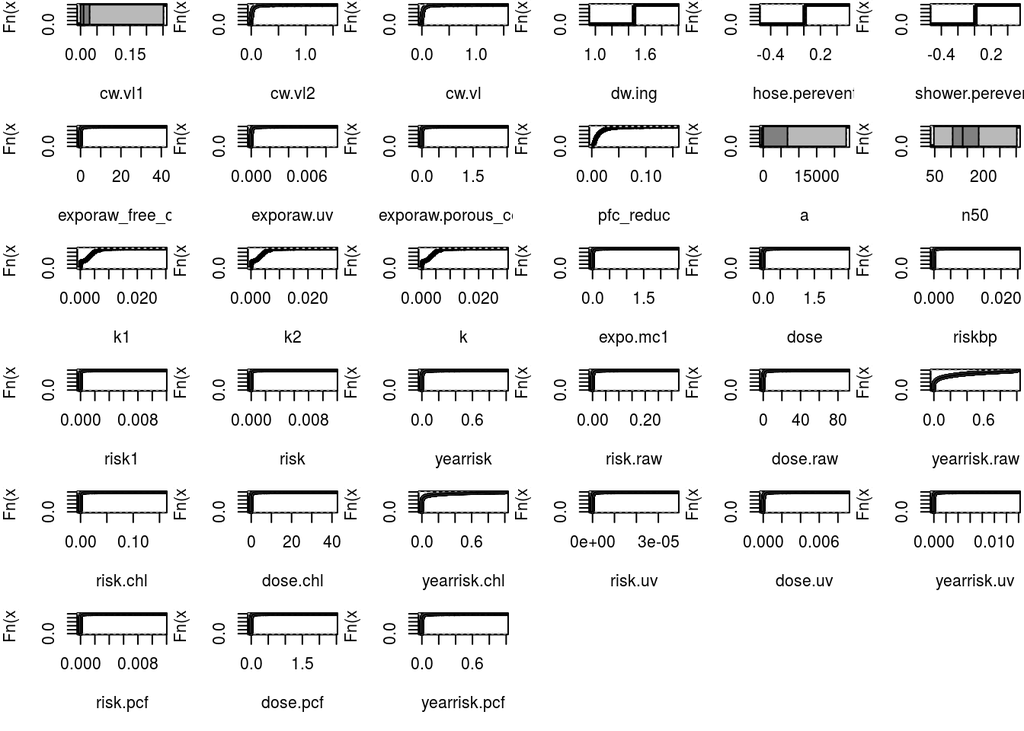

```r
# Plot the results.
plot(expo.ev1)
```

Report the mean and median of the exposure means with a 95% confidence interval (CI95).

```r
mean.expo <- sapply(1:ndunc(), function(j) mean(expo.ev1$expo.mc1[, j, ]))
mean(mean.expo)
```

```
## [1] 0.009794498
```

```r
quantile(mean.expo, probs = seq(0, 1, 0.025))[c("2.5%", "50%", "97.5%")]
```

```
##        2.5%         50%       97.5%
## 0.005988193 0.009224485 0.016763489
```

Report the mean and median of the DAILY risk probability means with a 95% confidence interval (CI95).

```r
mean.risk <- sapply(1:ndunc(), function(j) mean(expo.ev1$risk[, j, ]))
mean(mean.risk)
```

```
## [1] 2.720638e-05
```

```r
quantile(mean.risk, probs = seq(0, 1, 0.025))[c("2.5%", "50%", "97.5%")]
```

```
##         2.5%          50%        97.5%
## 1.412635e-05 2.380064e-05 5.631985e-05
```

Report the mean and median of the YEARLY risk probability means with a 95% confidence interval (CI95).

```r
mean.yearrisk <- sapply(1:ndunc(), function(j) mean(expo.ev1$yearrisk[, j, ]))
mean(mean.yearrisk)
```

```
## [1] 0.007999909
```

```r
quantile(mean.yearrisk, probs = seq(0, 1, 0.025))[c("2.5%", "50%", "97.5%")]
```

```
##        2.5%         50%       97.5%
## 0.004950935 0.007796629 0.011714219
```

Plot the empirical cumulative distribution function (ecdf) of the exposure model (`expo.mc1`) estimates.

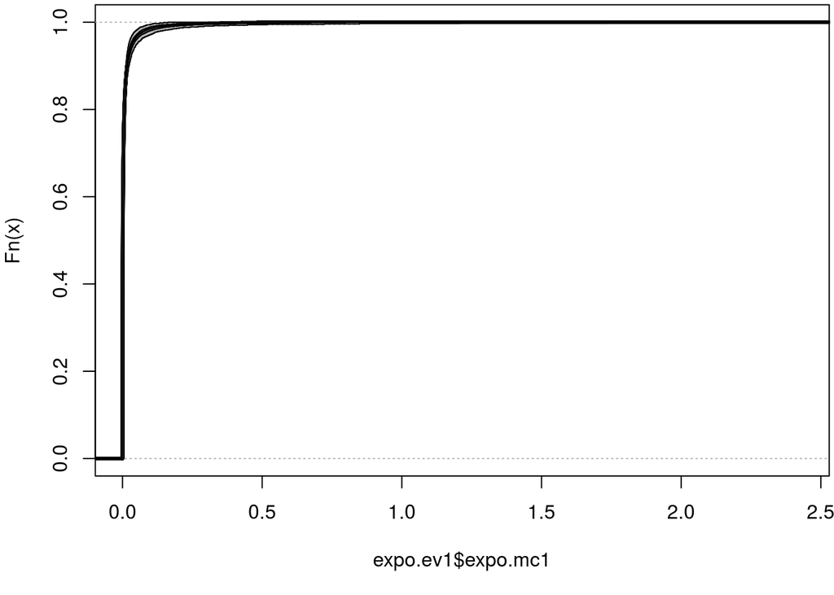

```r
# Generate an "ecdf" plot. This actually calls plot.mcnode().
plot(expo.ev1$expo.mc1)
```

Plot the empirical cumulative distribution function (ecdf) of the risk model (`risk`) estimates.

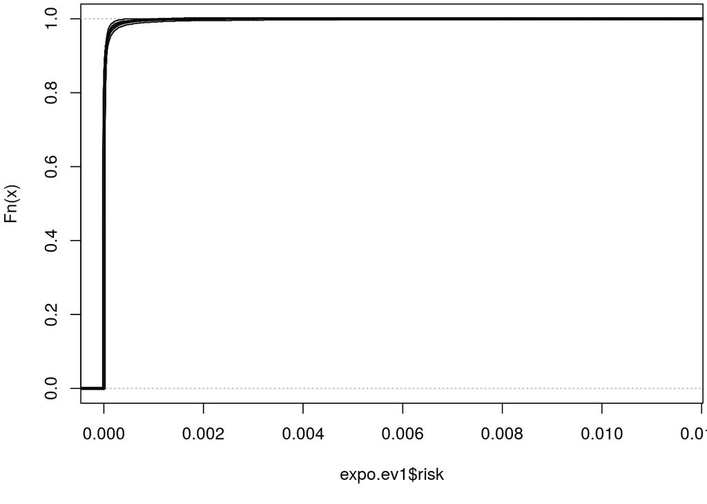

```r
# Generate an "ecdf" plot. This actually calls plot.mcnode().
plot(expo.ev1$risk)
```

Label the plot:

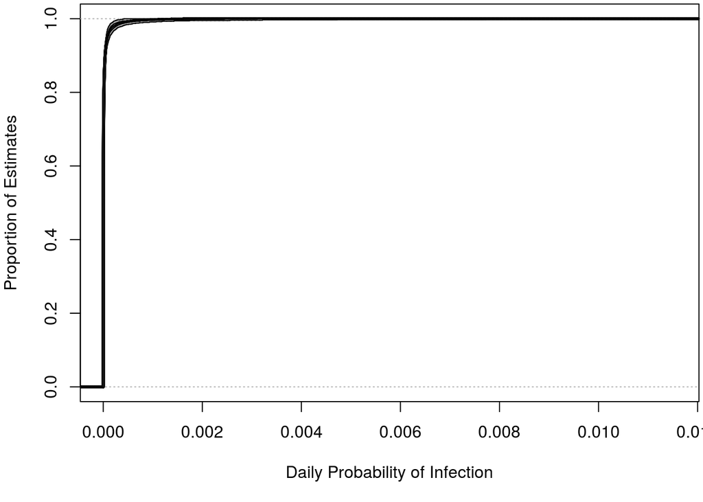

```r
# Generate an "ecdf" plot. This actually calls plot.mcnode().
plot(expo.ev1$risk, main = "", ylab = "Proportion of Estimates", xlab = "Daily Probability of Infection")
title("Daily Infec. Risk with Cryptosporidium by RCRW
in the USVI", cex.main = 1, font.main= 1, line = 7)
```

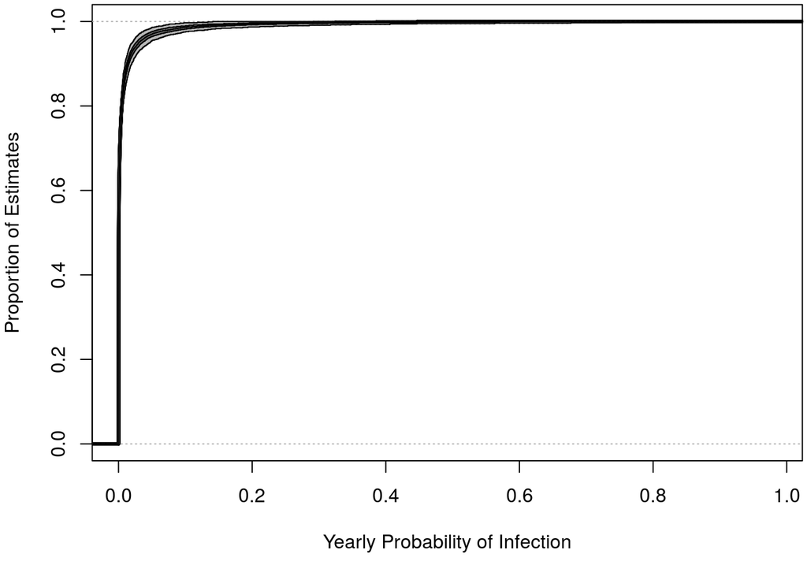

```r
# Generate an "ecdf" plot. This actually calls plot.mcnode().
plot(expo.ev1$yearrisk, main = "", ylab = "Proportion of Estimates", xlab = "Yearly Probability of Infection")
title("Yearly Infec. Risk with Cryptosporidium by RCRW
in the USVI", cex.main = 1, font.main= 1, line = 7)
```

RAW:

Report the mean and median of the DAILY risk probability means with a 95% confidence interval (CI95).

```r
mean.risk.raw <- sapply(1:ndunc(), function(j) mean(expo.ev1$risk.raw[, j, ]))
mean(mean.risk.raw)
```

```
## [1] 0.001802708
```

```r
quantile(mean.risk.raw, probs = seq(0, 1, 0.025))[c("2.5%", "50%", "97.5%")]
```

```
##        2.5%         50%       97.5%
## 0.001110250 0.001696429 0.003046065
```

Report the mean and median of the YEARLY risk probability means with a 95% confidence interval (CI95).

```r
mean.yearrisk.raw <- sapply(1:ndunc(), function(j) mean(expo.ev1$yearrisk.raw[, j, ]))
mean(mean.yearrisk.raw)
```

```
## [1] 0.1862742
```

```r
quantile(mean.yearrisk.raw, probs = seq(0, 1, 0.025))[c("2.5%", "50%", "97.5%")]
```

```
##      2.5%       50%     97.5%
## 0.1632300 0.1860415 0.2095665
```

Plot the empirical cumulative distribution function (ecdf) of the risk model (`risk`) estimates.

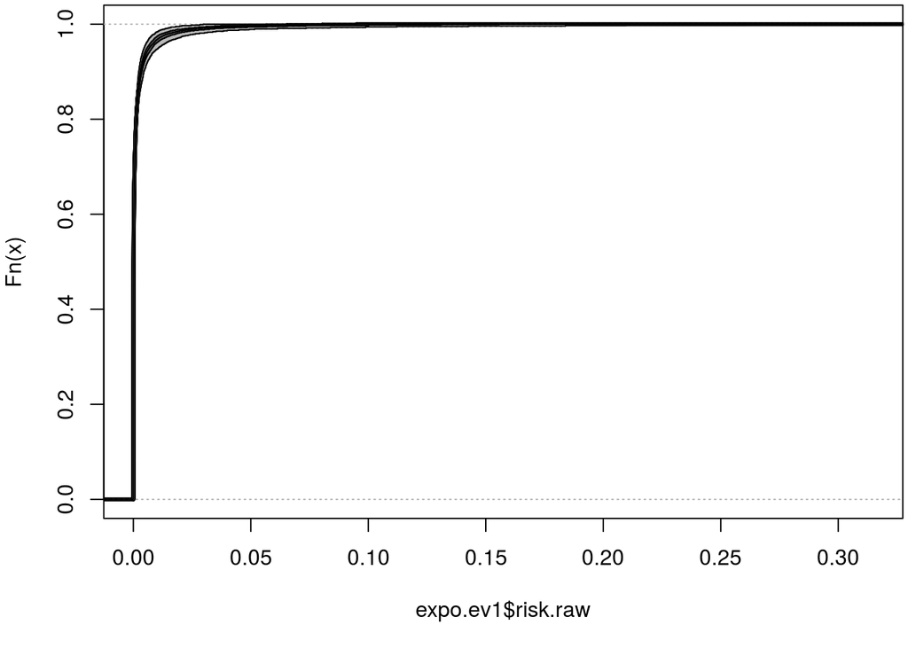

```r
# Generate an "ecdf" plot. This actually calls plot.mcnode().
plot(expo.ev1$risk.raw)
```

Label the plot:

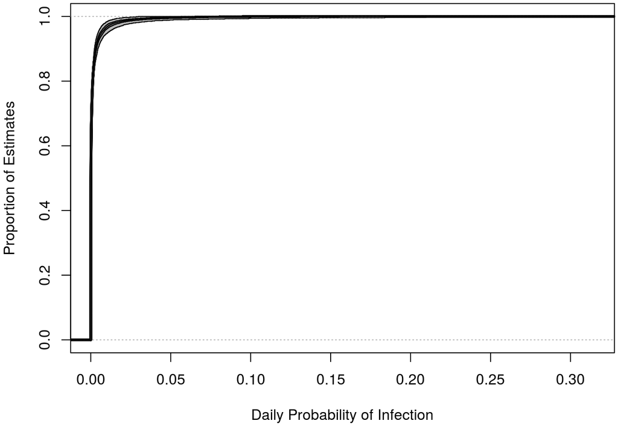

```r
# Generate an "ecdf" plot. This actually calls plot.mcnode().
plot(expo.ev1$risk.raw, main = "", ylab = "Proportion of Estimates", xlab = "Daily Probability of Infection")
title("Daily Infec. Risk with Cryptosporidium by RCRW
from Raw Water", cex.main = 1, font.main= 1, line = 7)
```

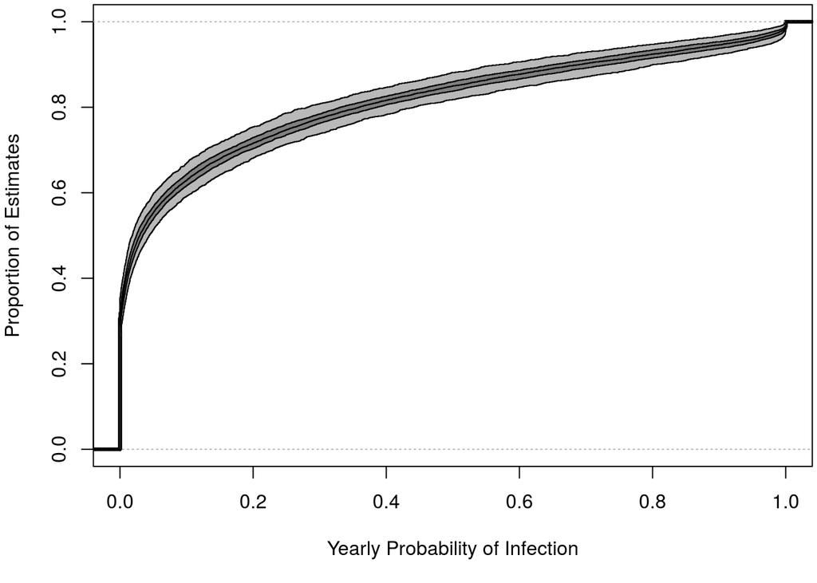

```r
# Generate an "ecdf" plot. This actually calls plot.mcnode().
plot(expo.ev1$yearrisk.raw, main = "", ylab = "Proportion of Estimates", xlab = "Yearly Probability of Infection")
title("Yearly Infec. Risk with Cryptosporidium by RCRW
from Raw Water", cex.main = 1, font.main= 1, line = 7)
```

CHLORINATED:

Report the mean and median of the DAILY risk probability means with a 95% confidence interval (CI95).

```r
mean.risk.chl <- sapply(1:ndunc(), function(j) mean(expo.ev1$risk.chl[, j, ]))
mean(mean.risk.chl)
```

```
## [1] 0.0004964692
```

```r
quantile(mean.risk.chl, probs = seq(0, 1, 0.025))[c("2.5%", "50%", "97.5%")]
```

```
##         2.5%          50%        97.5%
## 0.0002707070 0.0004515976 0.0009971264
```

Report the mean and median of the YEARLY risk probability means with a 95% confidence interval (CI95).

```r
mean.yearrisk.chl <- sapply(1:ndunc(), function(j) mean(expo.ev1$yearrisk.chl[, j, ]))
mean(mean.yearrisk.chl)
```

```
## [1] 0.07056085
```

```r
quantile(mean.yearrisk.chl, probs = seq(0, 1, 0.025))[c("2.5%", "50%", "97.5%")]
```

```
##       2.5%        50%      97.5%
## 0.05481335 0.07047081 0.08536805
```

Plot the empirical cumulative distribution function (ecdf) of the risk model (`risk`) estimates.

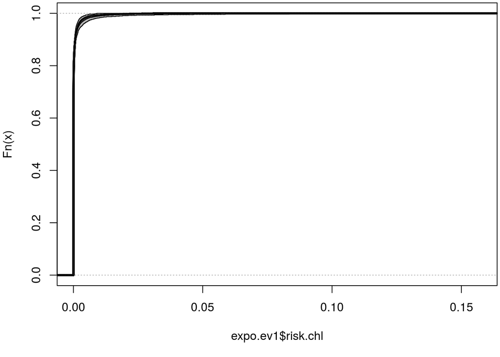

```r
# Generate an "ecdf" plot. This actually calls plot.mcnode().
plot(expo.ev1$risk.chl)
```

Label the plot:

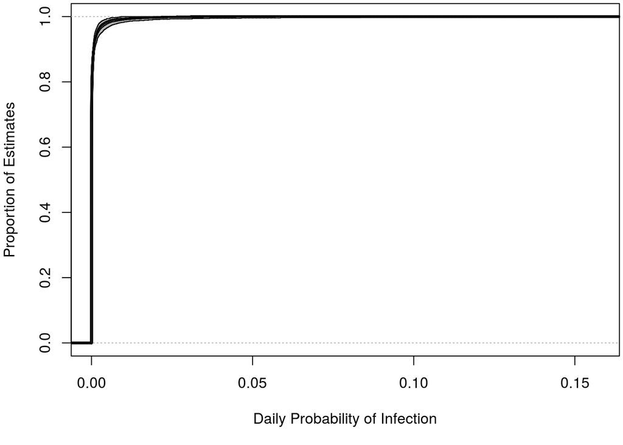

```r
# Generate an "ecdf" plot. This actually calls plot.mcnode().
plot(expo.ev1$risk.chl, main = "", ylab = "Proportion of Estimates", xlab = "Daily Probability of Infection")
title("Daily Infec. Risk with Cryptosporidium by RCRW
from Chlorinated Water", cex.main = 1, font.main= 1, line = 7)
```

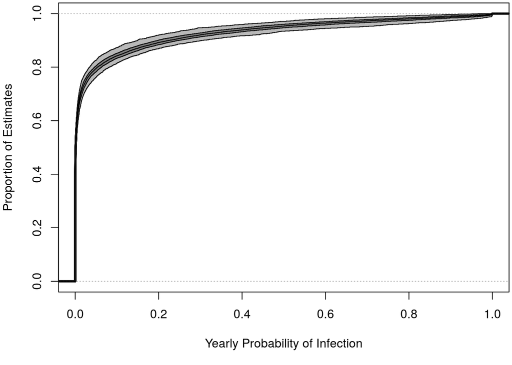

```r
# Generate an "ecdf" plot. This actually calls plot.mcnode().
plot(expo.ev1$yearrisk.chl, main = "", ylab = "Proportion of Estimates", xlab = "Yearly Probability of Infection")
title("Yearly Infec. Risk with Cryptosporidium by RCRW
from Chlorinated Water", cex.main = 1, font.main= 1, line = 7)
```

UV TREATED:

Report the mean and median of the DAILY risk probability means with a 95% confidence interval (CI95).

```r
mean.risk.uv <- sapply(1:ndunc(), function(j) mean(expo.ev1$risk.uv[, j, ]))
mean(mean.risk.uv)
```

```
## [1] 1.857042e-07
```

```r
quantile(mean.risk.uv, probs = seq(0, 1, 0.025))[c("2.5%", "50%", "97.5%")]
```

```
##         2.5%          50%        97.5%
## 1.116494e-07 1.730979e-07 3.190292e-07
```

Report the mean and median of the YEARLY risk probability means with a 95% confidence interval (CI95).

```r
mean.yearrisk.uv <- sapply(1:ndunc(), function(j) mean(expo.ev1$yearrisk.uv[, j, ]))
mean(mean.yearrisk.uv)
```

```
## [1] 6.770449e-05
```

```r
quantile(mean.yearrisk.uv, probs = seq(0, 1, 0.025))[c("2.5%", "50%", "97.5%")]
```

```
##         2.5%          50%        97.5%
## 4.074368e-05 6.312336e-05 1.160772e-04
```

Plot the empirical cumulative distribution function (ecdf) of the risk model (`risk`) estimates.

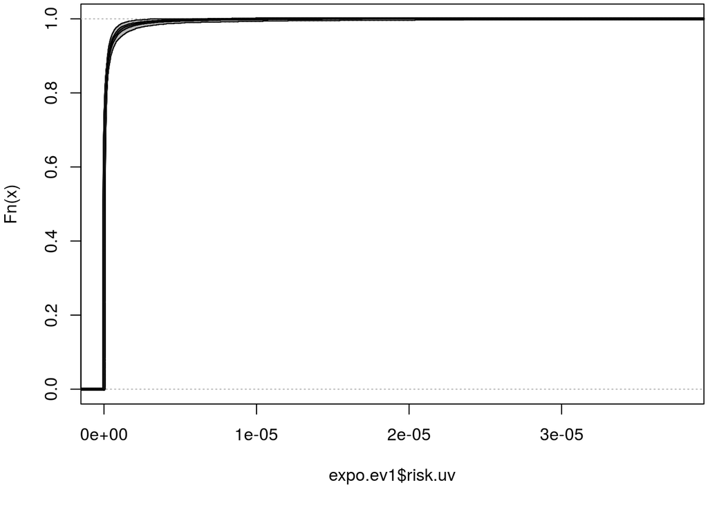

```r
# Generate an "ecdf" plot. This actually calls plot.mcnode().
plot(expo.ev1$risk.uv)
```

Label the plot:

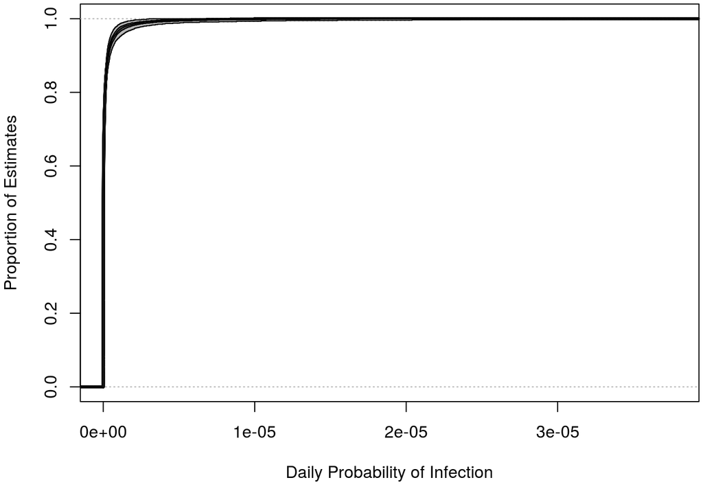

```r
# Generate an "ecdf" plot. This actually calls plot.mcnode().
plot(expo.ev1$risk.uv, main = "", ylab = "Proportion of Estimates", xlab = "Daily Probability of Infection")
title("Daily Infec. Risk with Cryptosporidium by RCRW
from UV Treated Water", cex.main = 1, font.main= 1, line = 7)
```

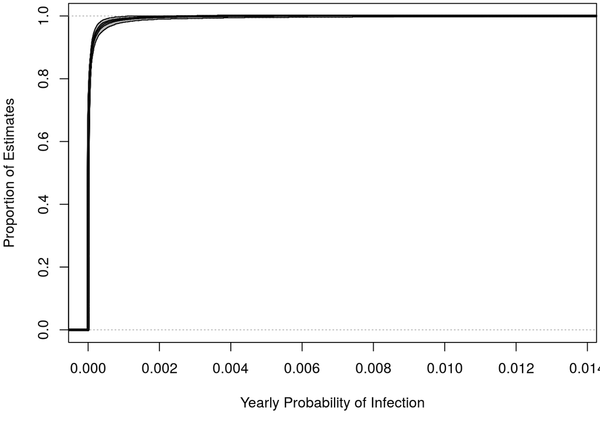

```r
# Generate an "ecdf" plot. This actually calls plot.mcnode().
plot(expo.ev1$yearrisk.uv, main = "", ylab = "Proportion of Estimates", xlab = "Yearly Probability of Infection")
title("Yearly Infec. Risk with Cryptosporidium by RCRW
from UV Treated Water", cex.main = 1, font.main= 1, line = 7)
```

POROUS CERAMIC FILTRATION:

Report the mean and median of the DAILY risk probability means with a 95% confidence interval (CI95).

```r
mean.risk.pcf <- sapply(1:ndunc(), function(j) mean(expo.ev1$risk.pcf[, j, ]))
mean(mean.risk.pcf)
```

```
## [1] 2.720638e-05
```

```r
quantile(mean.risk.pcf, probs = seq(0, 1, 0.025))[c("2.5%", "50%", "97.5%")]
```

```
##         2.5%          50%        97.5%
## 1.412635e-05 2.380064e-05 5.631985e-05
```

Report the mean and median of the YEARLY risk probability means with a 95% confidence interval (CI95).

```r
mean.yearrisk.pcf <- sapply(1:ndunc(), function(j) mean(expo.ev1$yearrisk.pcf[, j, ]))
mean(mean.yearrisk.pcf)
```

```
## [1] 0.007999909
```

```r
quantile(mean.yearrisk.pcf, probs = seq(0, 1, 0.025))[c("2.5%", "50%", "97.5%")]
```

```
##        2.5%         50%       97.5%
## 0.004950935 0.007796629 0.011714219
```

Plot the empirical cumulative distribution function (ecdf) of the risk model (`risk`) estimates.

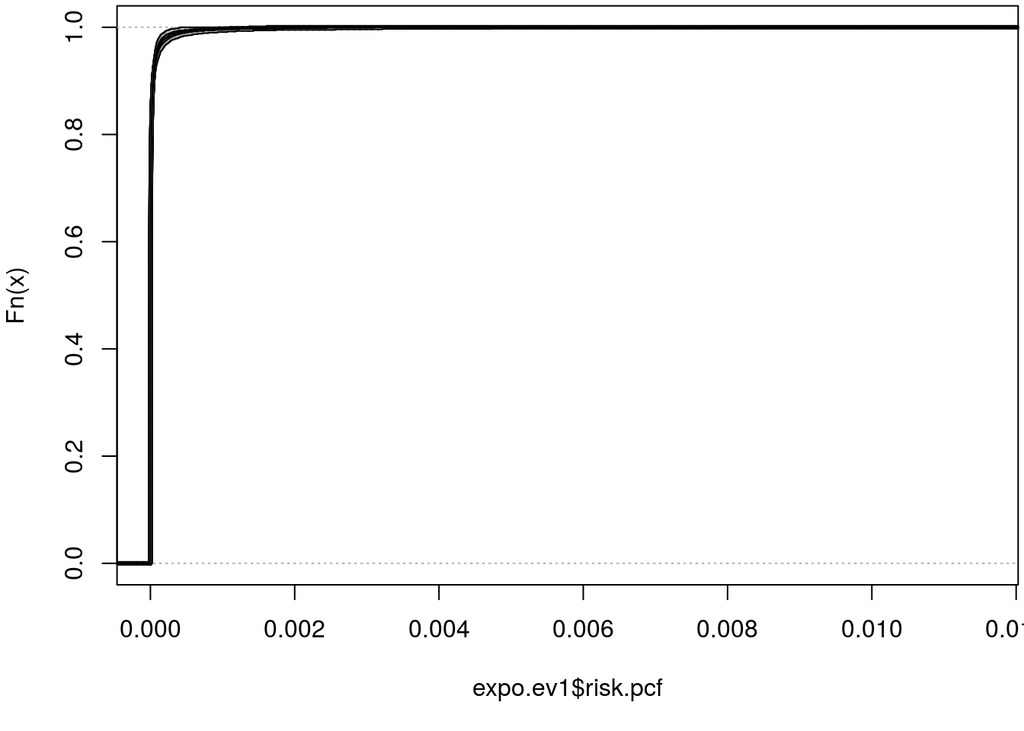

```r
# Generate an "ecdf" plot. This actually calls plot.mcnode().
plot(expo.ev1$risk.pcf)
```

Label the plot:

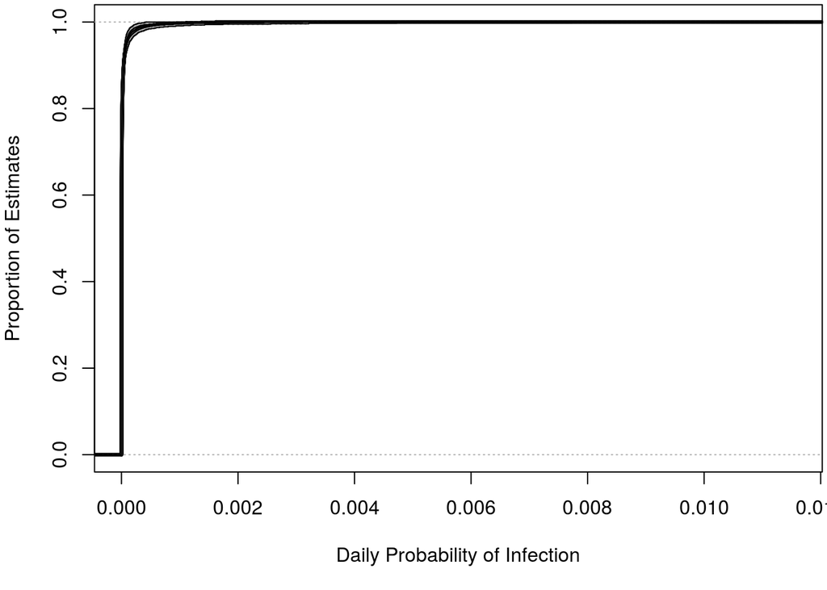

```r
# Generate an "ecdf" plot. This actually calls plot.mcnode().
plot(expo.ev1$risk.pcf, main = "", ylab = "Proportion of Estimates", xlab = "Daily Probability of Infection")
title("Daily Infec. Risk with Cryptosporidium by RCRW
from Water Treated with PCF", cex.main = 1, font.main= 1, line = 7)
```

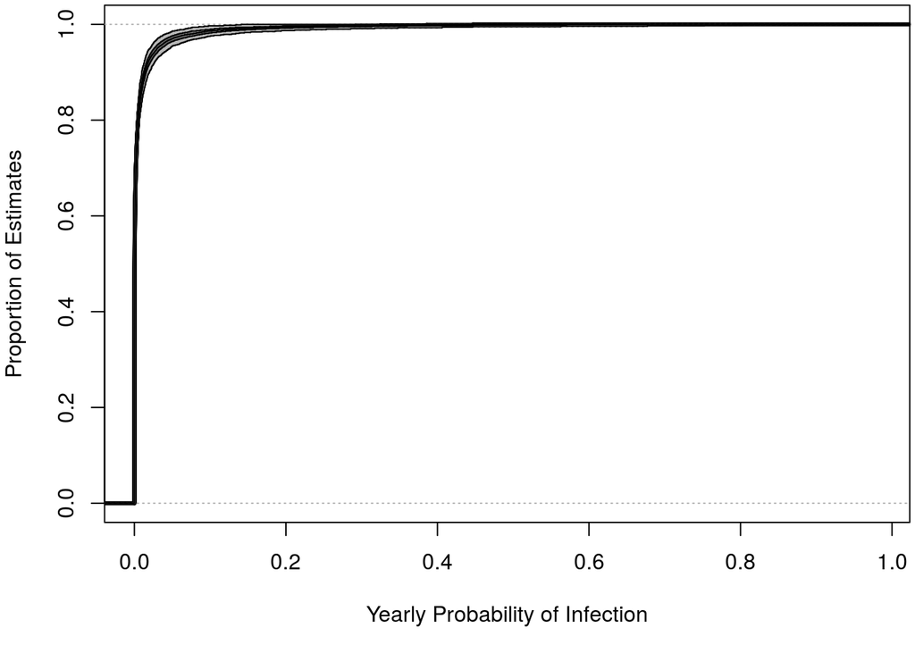

```r
# Generate an "ecdf" plot. This actually calls plot.mcnode().
plot(expo.ev1$yearrisk.pcf, main = "", ylab = "Proportion of Estimates", xlab = "Yearly Probability of Infection")
title("Yearly Infec. Risk with Cryptosporidium by RCRW
from Water Treated with PCF", cex.main = 1, font.main= 1, line = 7)
```

Manually remake the graph, this time using yearrisk, which should just be another mcnode object with all values between 0 and 1:

The first one plots yearrisk without a log x scale:

```r
library(reshape)
```

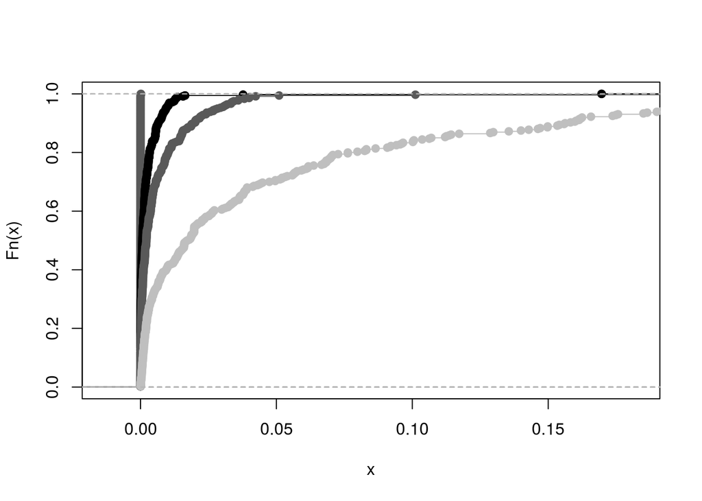

```r
library(ggplot2)
Risk.mat.1 <- expo.ev1$yearrisk[,,]
probs1 <- c(0.025, 0.25, 0.50, 0.75, 0.975)
quant1 <- as.data.frame(t(apply(Risk.mat.1, 1, quantile, probs = probs1)))
ecdfs1 <- sapply(names(quant1), function(q) ecdf(quant1[[q]]))
plot(ecdfs1[['50%']], main = '')
grays <- c('gray75', 'gray35', 'black', 'gray35', 'gray75')
lines <- mapply(function(e, g) lines(e, col = g), ecdfs1, grays)
```

Plotting yearrisk ECDF plot with ggplot2:

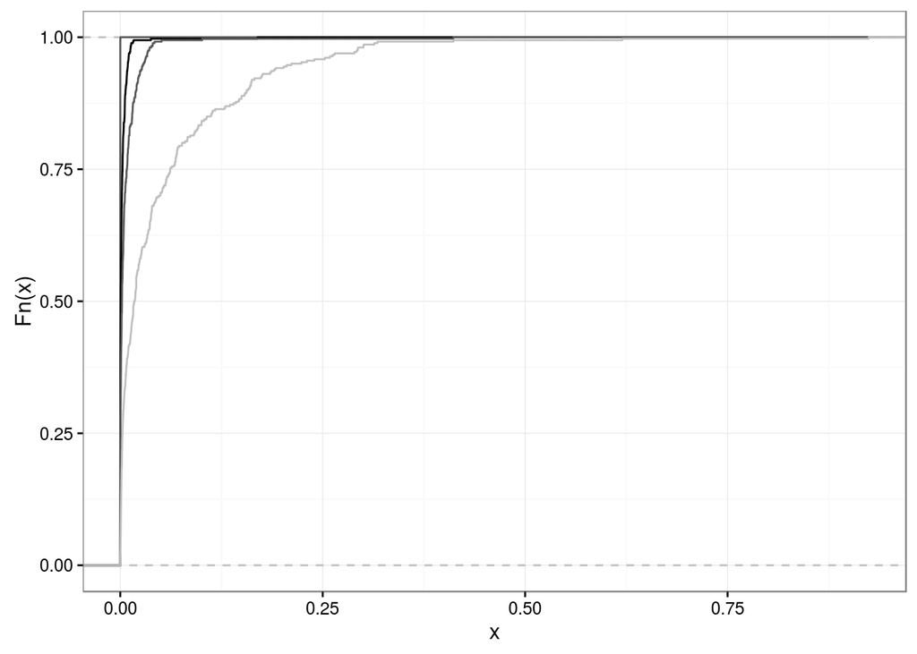

```r
quant.melt1 <- suppressMessages(melt(quant1))
names(quant.melt1) <- c('q', 'x')
grays <- c('gray75', 'gray35', 'black', 'gray35', 'gray75')
ggplot(quant.melt1, aes(x = x)) + theme_bw() + theme(legend.position = 'none') + geom_hline(yintercept = c(0, 1), linetype = "dashed", color = 'gray') + stat_ecdf(aes(group = q, color = q)) + xlab('x') + ylab('Fn(x)') + scale_colour_manual(values = grays)
```

Plot Version 2 with ggplot2, and a log-scale x axis:

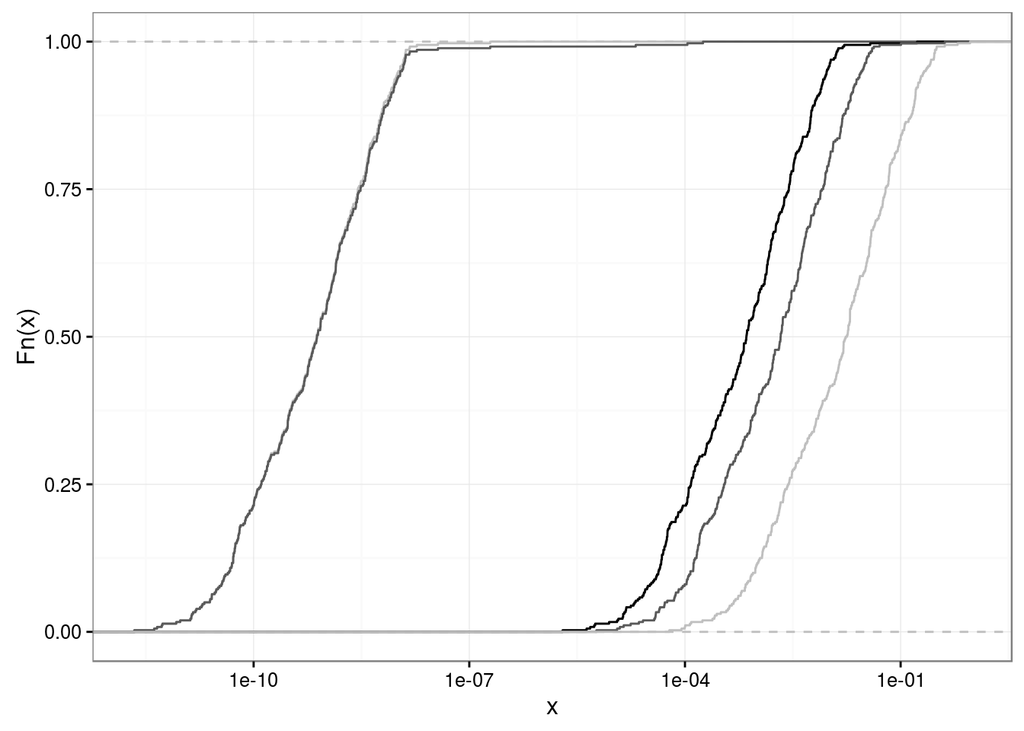

```r
quant.melt1 <- suppressMessages(melt(quant1))
names(quant.melt1) <- c('q', 'x')
grays <- c('gray75', 'gray35', 'black', 'gray35', 'gray75')
ggplot(quant.melt1, aes(x = x)) + theme_bw() + theme(legend.position = 'none') + geom_hline(yintercept = c(0, 1), linetype = "dashed", color = 'gray') + stat_ecdf(aes(group = q, color = q)) + xlab('x') + ylab('Fn(x)') + scale_colour_manual(values = grays) + scale_x_log10()
```